# EDA

Si Chen 2023-12-06

```r
library(tidyr)
library(tidyverse)
library(rvest)
library(dplyr)
library(cowplot)
library(gridExtra)
library(RColorBrewer)

knitr::opts_chunk$set(
    echo = TRUE,
    warning = FALSE,
    fig.width = 8,
  fig.height = 6,
  out.width = "90%"
)

theme_set(theme_minimal() + theme(legend.position = "bottom"))

options(
  ggplot2.continuous.colour = "viridis",
  ggplot2.continuous.fill = "viridis"
)

scale_colour_discrete = scale_colour_viridis_d
scale_fill_discrete = scale_fill_viridis_d
```

### Load clean datasets

```r
df_2013 =
  read_csv("data/merge_data_2013.csv", show_col_types = FALSE)
df_2017 =
  read_csv("data/merge_data_2017.csv", show_col_types = FALSE)
# Convert month to factor with levels in ascending order and labels as month abbreviations
df_2013$month <- factor(df_2013$month, levels = 1:12, labels = month.abb[1:12])
```

### Data set description

In the dataset for 2013, there are 20 columns and 72734 rows. In the dataset for 2017, there are 20 columns and 4785 rows.

There are 16 different carriers flying out of NYC airports. NYC has 3 different airports. There are 104 different destination locations to which flights fly out of NYC airports.

TBC…

# Weather

Visualize association between weather variables? aggregate by date, plot scatter plot, add fitted line (instead of by month)?

```r
# Aggregate the data by month and calculate averages
df_2013_avg <- df_2013 %>%
  group_by(month) %>%
  summarize(
    avg_arr_delay = mean(arr_delay, na.rm = TRUE),
    avg_precip = mean(precip, na.rm = TRUE),
    avg_wind_dir = mean(wind_dir, na.rm = TRUE),
    avg_wind_speed = mean(wind_speed, na.rm = TRUE),
    avg_wind_gust = mean(wind_gust, na.rm = TRUE),
    avg_pressure = mean(pressure, na.rm = TRUE),
    avg_visib = mean(visib, na.rm = TRUE)
  )
```

## Preciptation 2013

```r
# Plot precipitation against arrival delay in a scatter plot
precip_delay =
  ggplot(df_2013, aes(x = precip, y = arr_delay)) +
  geom_point(alpha = 0.5, color = "skyblue") +
  labs(title = "Scatter Plot of Precipitation against Arrival Delay",
       x = "Precipitation (inches)",
       y = "Arrival Delay (minutes)")
```

```r
# Average precip against average arr_delay by month
precip_delay_month =
  ggplot(df_2013_avg, aes(x = avg_precip, y = avg_arr_delay, color = month)) +
  geom_point(size = 3) +
  geom_smooth(method = "lm", se = FALSE, color = "coral", size = 0.6) +
  labs(title = "Scatter Plot of Precipitation against Arrival Delay",
       x = "Precipitation (inches)",
       y = "Arrival Delay (minutes)")
```

```r
# grid.arrange(precip_line_bar, precip_delay, nrow = 2)
# precip_violin
# precip_line
# precip_bar
summary(df_2013$precip)
```

```
##     Min.  1st Qu.   Median     Mean  3rd Qu.     Max.
## 0.000000 0.000000 0.000000 0.001352 0.000000 0.530000
```

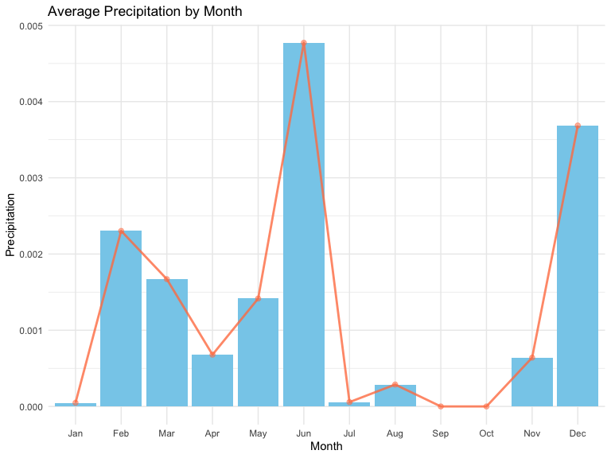

```r
precip_line_bar
```

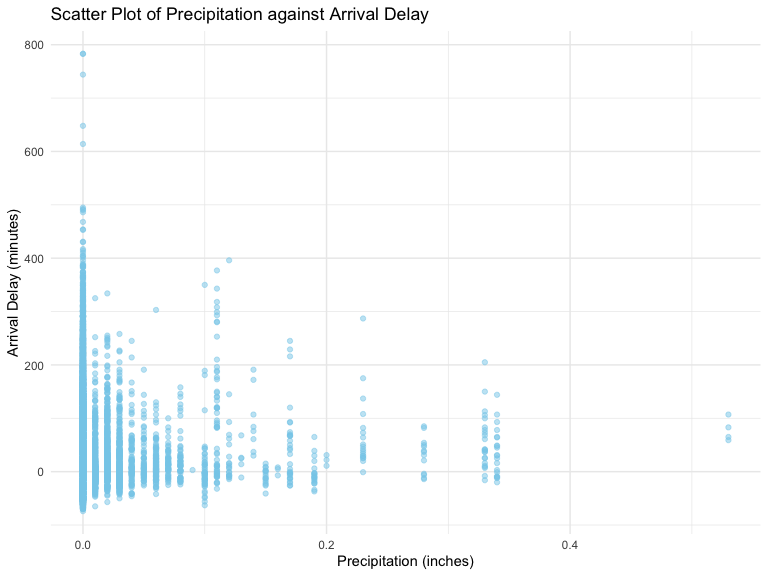

```r
precip_delay
```

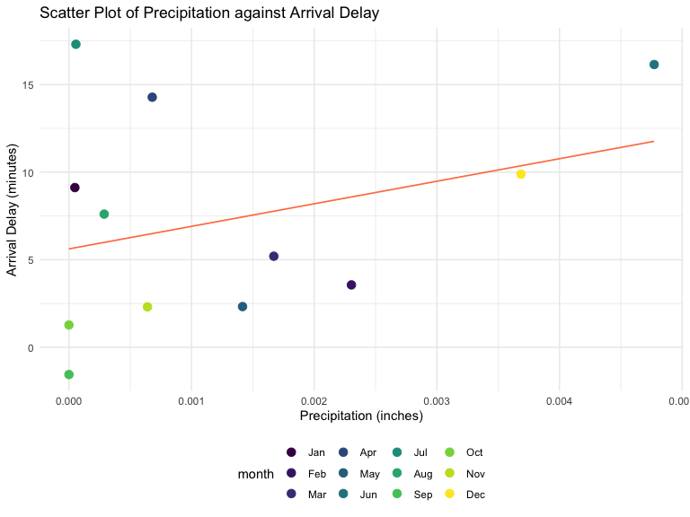

```r
precip_delay_month
```

## Pressure

```r
# Plot average pressure by month in line plot
pressure_line =
  ggplot(df_2013, aes(x = month, y = pressure))  +
  #geom_bar(aes(x=month, y=pressure),stat="summary", fun = 'mean', fill="skyblue")+
  geom_point(aes(x=month, y=pressure), stat = "summary", fun = "mean", color = "coral", alpha = .8) +
  geom_line(aes(group = 1), stat="summary", fun = 'mean', color="skyblue", size=1, alpha = .8) +
  labs(
    title= "Average Pressure by Month",
    x="Month",
    y="Pressure")

# Plot Pressure against arrival delay in a scatter plot
pressure_delay =
  ggplot(df_2013, aes(x = pressure, y = arr_delay)) +
  geom_point(alpha = 0.5, color = "skyblue") +
  labs(title = "Scatter Plot of Pressure against Arrival Delay",
       x = "Pressure",
       y = "Arrival Delay (minutes)")

# Average pressure against average arr_delay by month
pressure_delay_month =
  ggplot(df_2013_avg, aes(x = avg_pressure, y = avg_arr_delay, color = month)) +
  geom_point(size = 3) +
  geom_smooth(method = "lm", se = FALSE, color = "coral", size = 0.6) +
  labs(title = "Scatter Plot of Average Pressure against Arrival Delay by Month",
       x = "Avg Monthly Pressure",
       y = "Avg Arrival Delay (minutes)")
```

```r
summary(df_2013$pressure)
```

```
##    Min. 1st Qu.  Median    Mean 3rd Qu.    Max.
##   983.8  1010.8  1015.4  1015.6  1020.4  1040.4
```

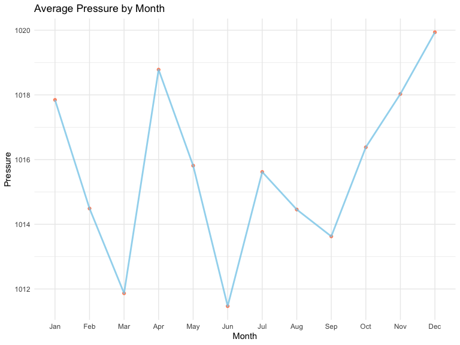

```r
pressure_line
```

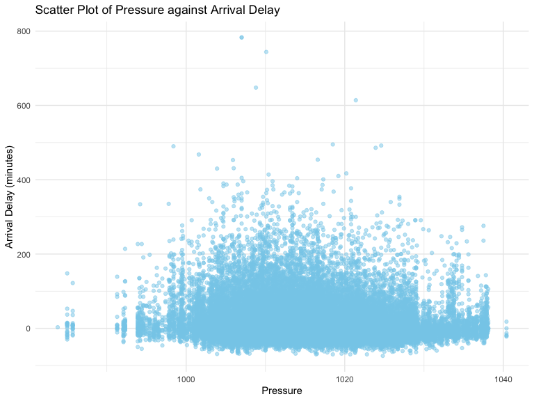

```r
pressure_delay
```

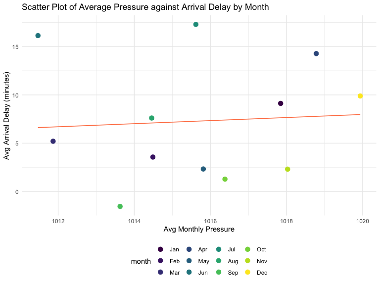

```r
pressure_delay_month
```

## Visibility

```r
# Plot average Visibility by month in line plot
visib_line =
  ggplot(df_2013, aes(x = month, y = visib))  +
  # geom_bar(aes(x=month, y=visib),stat="summary", fun = 'mean', fill="skyblue")+
  geom_point(aes(x=month, y=visib), stat = "summary", fun = "mean", color = "coral") +
  geom_line(aes(group = 1), stat="summary", fun = 'mean', color="skyblue", size=1, alpha = .8) +
  labs(
    title= "Average Visibility by Month",
    x="Month",
    y="Visibility")

# Plot Visibility against arrival delay in a scatter plot
visib_delay =
  ggplot(df_2013, aes(x = visib, y = arr_delay)) +
  geom_point(alpha = 0.5, color = "skyblue") +
  labs(title = "Scatter Plot of Visibility against Arrival Delay",
       x = "Visibility",
       y = "Arrival Delay (minutes)")

# Average Visibility against average arr_delay by month
visib_delay_month =
  ggplot(df_2013_avg, aes(x = avg_visib, y = avg_arr_delay, color = month)) +
  geom_point(size = 3) +
  geom_smooth(method = "lm", se = FALSE, color = "coral", size = 0.6) +
  labs(title = "Scatter Plot of Average Visibility against Arrival Delay by Month",
       x = "Avg Monthly Visibility",
       y = "Avg Arrival Delay (minutes)")
```

```r
summary(df_2013$visib)
```

```
##    Min. 1st Qu.  Median    Mean 3rd Qu.    Max.
##   0.120  10.000  10.000   9.803  10.000  10.000
```

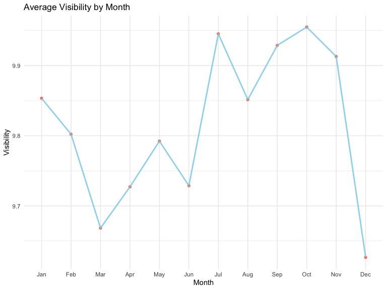

```r
visib_line
```

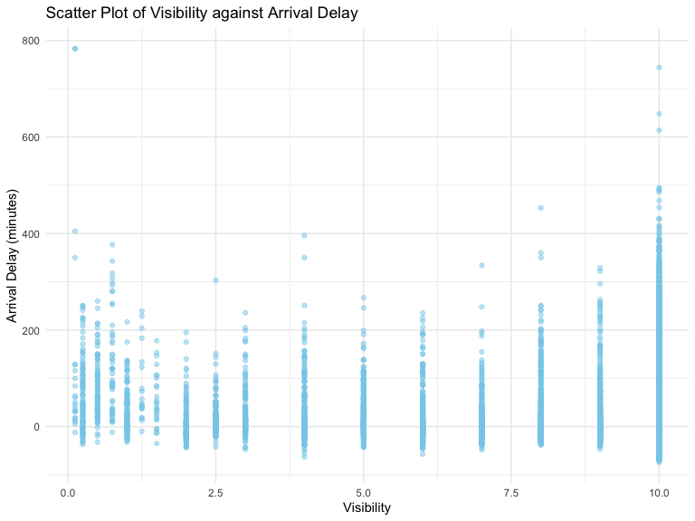

```r
visib_delay
```

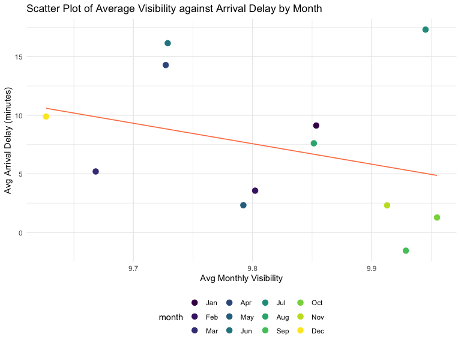

```r
visib_delay_month
```

## Wind Direction

```r
# Plot average wind_dir by month in line plot
wind_dir_line =
  ggplot(df_2013, aes(x = month, y = wind_dir))  +
  geom_bar(aes(x=month, y=wind_dir),stat="summary", fun = 'mean', fill="skyblue", alpha = .8)+
  geom_point(aes(x=month, y=wind_dir), stat = "summary", fun = "mean", color = "red") +
  geom_line(aes(group = 1), stat="summary", fun = 'mean', color="coral", size=1, alpha = .9) +
  labs(
    title= "Average Wind Direction by Month",
    x="Month",
    y="Wind Direction")

# Plot Wind Direction against arrival delay in a scatter plot
wind_dir_delay =
  ggplot(df_2013, aes(x = wind_dir, y = arr_delay)) +
  geom_point(alpha = 0.5, color = "skyblue") +
  labs(title = "Scatter Plot of Wind Direction against Arrival Delay",
       x = "Wind Direction",
       y = "Arrival Delay (minutes)")

# Average Wind Direction against average arr_delay by month
wind_dir_delay_month =
  ggplot(df_2013_avg, aes(x = avg_wind_dir, y = avg_arr_delay, color = month)) +
  geom_point(size = 3) +
  geom_smooth(method = "lm", se = FALSE, color = "coral", size = 0.6) +
  labs(title = "Scatter Plot of Average Wind Direction against Arrival Delay by Month",
       x = "Avg Monthly Wind Direction",
       y = "Avg Arrival Delay (minutes)")
```

```r
summary(df_2013$wind_dir)
```

```
##    Min. 1st Qu.  Median    Mean 3rd Qu.    Max.
##    10.0   220.0   280.0   253.9   310.0   360.0
```

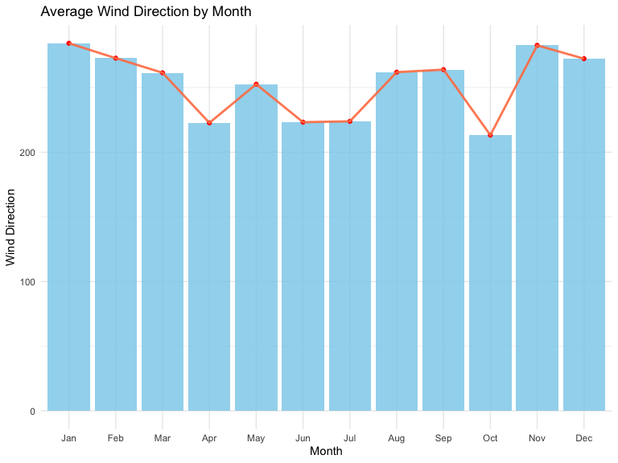

```r
wind_dir_line
```

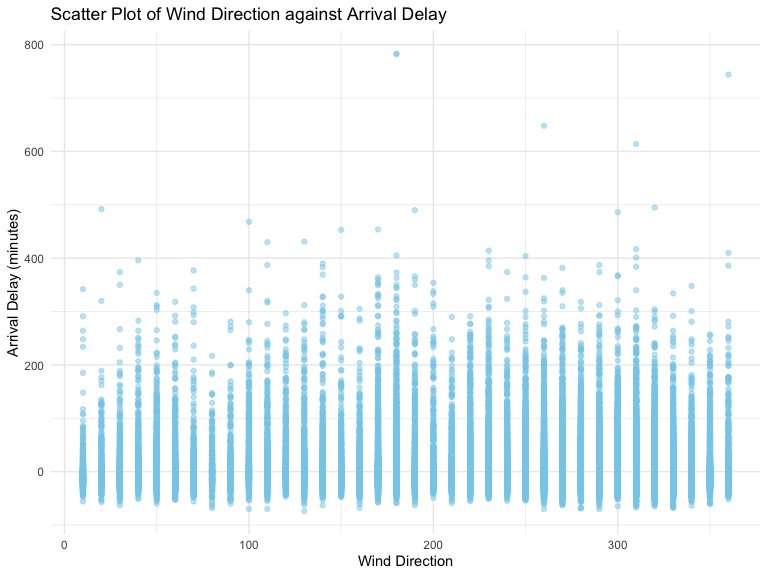

```r
wind_dir_delay
```

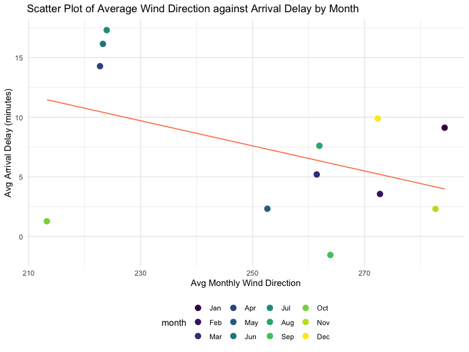

```r
wind_dir_delay_month
```

## Wind Speed

```r
# Plot average wind_speed by month in line plot
wind_speed_line =
  ggplot(df_2013, aes(x = month, y = wind_speed))  +
  geom_bar(aes(x=month, y=wind_speed),stat="summary", fun = 'mean', fill="skyblue", alpha = .8)+
  geom_point(aes(x=month, y=wind_speed), stat = "summary", fun = "mean", color = "red") +
  geom_line(aes(group = 1), stat="summary", fun = 'mean', color="coral", size=1, alpha = .8) +
  labs(
    title= "Average Wind Speed by Month",
    x="Month",
    y="Wind Speed")

# Plot wind_speed against arrival delay in a scatter plot
wind_speed_delay =
  ggplot(df_2013, aes(x = wind_speed, y = arr_delay)) +
  geom_point(alpha = 0.5, color = "skyblue") +
  labs(title = "Scatter Plot of Wind Speed against Arrival Delay",
       x = "Wind Speed",
       y = "Arrival Delay (minutes)")

# Average wind_speed against average arr_delay by month
wind_speed_delay_month =
  ggplot(df_2013_avg, aes(x = avg_wind_speed, y = avg_arr_delay, color = month)) +
  geom_point(size = 3) +
  geom_smooth(method = "lm", se = FALSE, color = "coral", size = 0.6) +
  labs(title = "Scatter Plot of Average Wind Speed against Arrival Delay by Month",
       x = "Avg Monthly Wind Speed",
       y = "Avg Arrival Delay (minutes)")
```

```r
summary(df_2013$wind_speed)
```

```
##    Min. 1st Qu.  Median    Mean 3rd Qu.    Max.
##   4.603  12.659  16.111  16.523  19.563  39.127
```

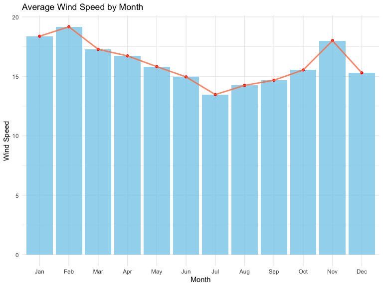

```r
wind_speed_line
```

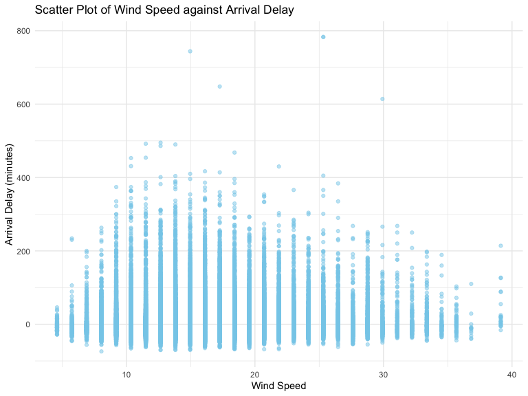

```r
wind_speed_delay
```

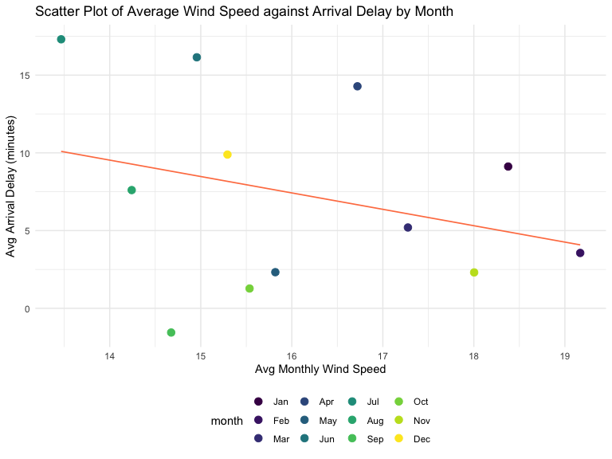

```r
wind_speed_delay_month
```

## Wind Gust

```r
# Plot average wind_gust by month in line plot
wind_gust_line =
  ggplot(df_2013, aes(x = month, y = wind_gust))  +
  geom_bar(aes(x=month, y=wind_gust),stat="summary", fun = 'mean', fill="skyblue", alpha = .8)+
  geom_point(aes(x=month, y=wind_gust), stat = "summary", fun = "mean", color = "red") +
  geom_line(aes(group = 1), stat="summary", fun = 'mean', color="coral", size=1, alpha = .8) +
  labs(
    title= "Average Wind Gust by Month",
    x="Month",
    y="Wind Gust")

# Plot wind_gust against arrival delay in a scatter plot
wind_gust_delay =
  ggplot(df_2013, aes(x = wind_gust, y = arr_delay)) +
  geom_point(alpha = 0.5, color = "skyblue") +
  labs(title = "Scatter Plot of Wind Gust against Arrival Delay",
       x = "Wind Gust",
       y = "Arrival Delay (minutes)")

# Average wind_gust against average arr_delay by month
wind_gust_delay_month =
  ggplot(df_2013_avg, aes(x = avg_wind_gust, y = avg_arr_delay, color = month)) +
  geom_point(size = 3) +
  geom_smooth(method = "lm", se = FALSE, color = "coral", size = 0.6) +
  labs(title = "Scatter Plot of Average Wind Gust against Arrival Delay by Month",
       x = "Avg Monthly Wind Gust",
       y = "Avg Arrival Delay (minutes)")
```

```r
summary(df_2013$wind_gust)
```

```
##    Min. 1st Qu.  Median    Mean 3rd Qu.    Max.
##   16.11   20.71   24.17   24.91   27.62   66.75
```

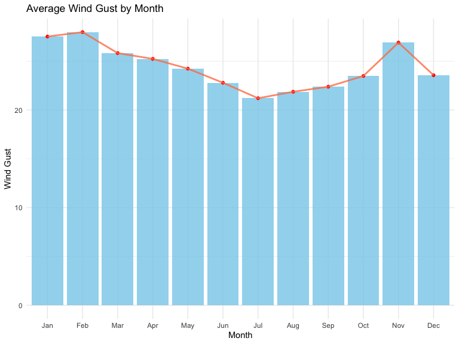

```r
wind_gust_line
```

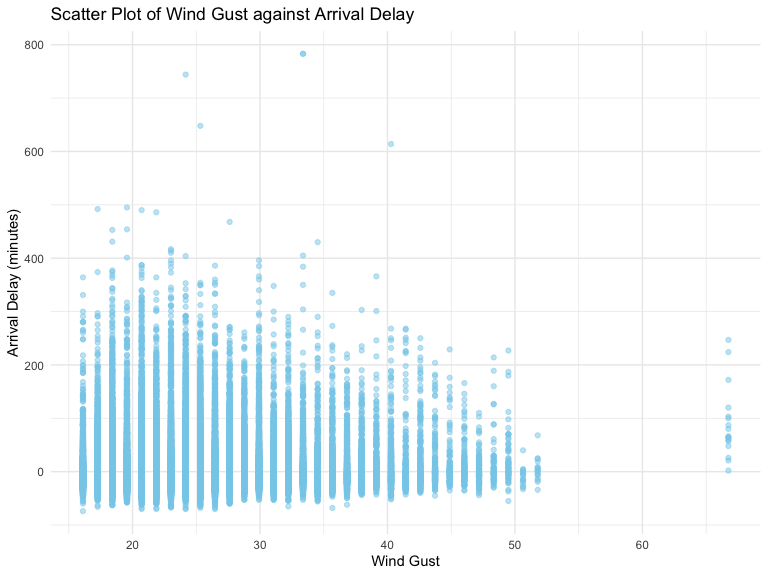

```r
wind_gust_delay
```

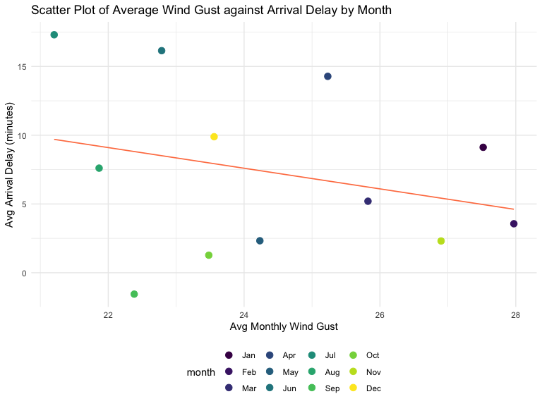

```r
wind_gust_delay_month
```